# FictionEro - Data Cleaning

## Data Preparation

```r
library(tidyverse)
library(easystats)
library(patchwork)
library(ggside)
```

```r
df <- read.csv("../data/rawdata_participants.csv") |>
  mutate(across(everything(), ~ifelse(.x == "", NA, .x))) |>
  mutate(Experimenter = case_when(
    Language=="English" & Experimenter == "reddit7" ~ "Reddit (other)",
    Language=="English" & Experimenter == "reddit8" ~ "Reddit (other)",
    Language=="English" & Experimenter == "reddit1" ~ "Reddit (other)",
    .default = Experimenter
  ))

dftask <- read.csv("../data/rawdata_task.csv") |>
  full_join(
    df[c("Participant", "Sex", "SexualOrientation")],
    by = join_by(Participant)
    )
```

The initial sample consisted of 386 participants (Mean age = 35.5, SD = 12.1, range: [18, 80]; Sex: 16.6% females, 82.1% males, 1.3% other; Education: Bachelor, 39.90%; Doctorate, 6.99%; High School, 24.09%; Master, 26.17%; Other, 1.55%; Primary School, 0.78%; Università (laurea magistrale) o equivalente, 0.52%; Country: 30.05% USA, 13.47% UK, 11.66% France, 44.82% other).

### Compute Scores

```r
# Create Sexual "relevance" variable (Relevant, irrelevant, non-erotic)
dftask <- dftask |>
  mutate(Relevance = case_when(
    Type == "Non-erotic" ~ "Non-erotic",
    Sex == "Male" & SexualOrientation == "Heterosexual" & Category == "Female" ~ "Relevant",
    Sex == "Female" & SexualOrientation == "Heterosexual" & Category == "Male" ~ "Relevant",
    Sex == "Male" & SexualOrientation == "Homosexual" & Category == "Male" ~ "Relevant",
    Sex == "Female" & SexualOrientation == "Homosexual" & Category == "Female" ~ "Relevant",
    # TODO: what to do with "Other"?
    SexualOrientation %in% c("Bisexual", "Other") & Category %in% c("Male", "Female") ~ "Relevant",
    .default = "Irrelevant"
  ))
```

### Recruitment History

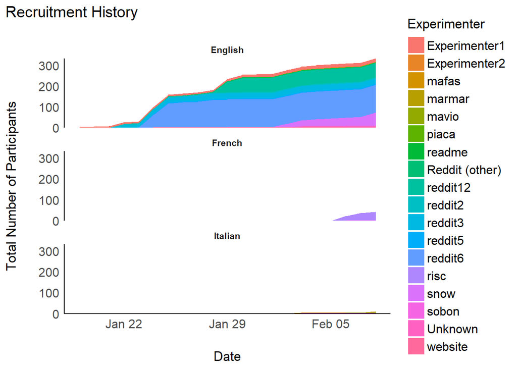

```r
# Consecutive count of participants per day (as area)
df |>
  mutate(Date = as.Date(Date, format = "%d/%m/%Y")) |>
  group_by(Date, Language, Experimenter) |>
  summarize(N = n()) |>
  ungroup() |>
  # https://bocoup.com/blog/padding-time-series-with-r
  complete(Date, Language, Experimenter, fill = list(N = 0)) |>
  group_by(Language, Experimenter) |>
  mutate(N = cumsum(N)) |>
  ggplot(aes(x = Date, y = N)) +
  geom_area(aes(fill=Experimenter)) +
  scale_y_continuous(expand = c(0, 0)) +
  labs(
    title = "Recruitment History",
    x = "Date",
    y = "Total Number of Participants"
  ) +
  facet_wrap(~Language, nrow=3) +
  see::theme_modern()
```

```r
# Table
summarize(df, N = n(), .by=c("Language", "Experimenter")) |>
  arrange(desc(N)) |>
  gt::gt() |>
  gt::opt_stylize() |>
  gt::opt_interactive(use_compact_mode = TRUE)
```

| Language | Experimenter | N |
| --- | --- | --- |
| English | reddit6 | 133 |
| English | reddit12 | 67 |
| English | snow | 62 |
| French | risc | 40 |
| English | reddit3 | 25 |
| English | Experimenter1 | 16 |
| English | reddit5 | 6 |
| English | Unknown | 6 |
| English | website | 5 |
| English | reddit2 | 5 |

[output cut: 9 more lines]

## Feedback

### Evaluation

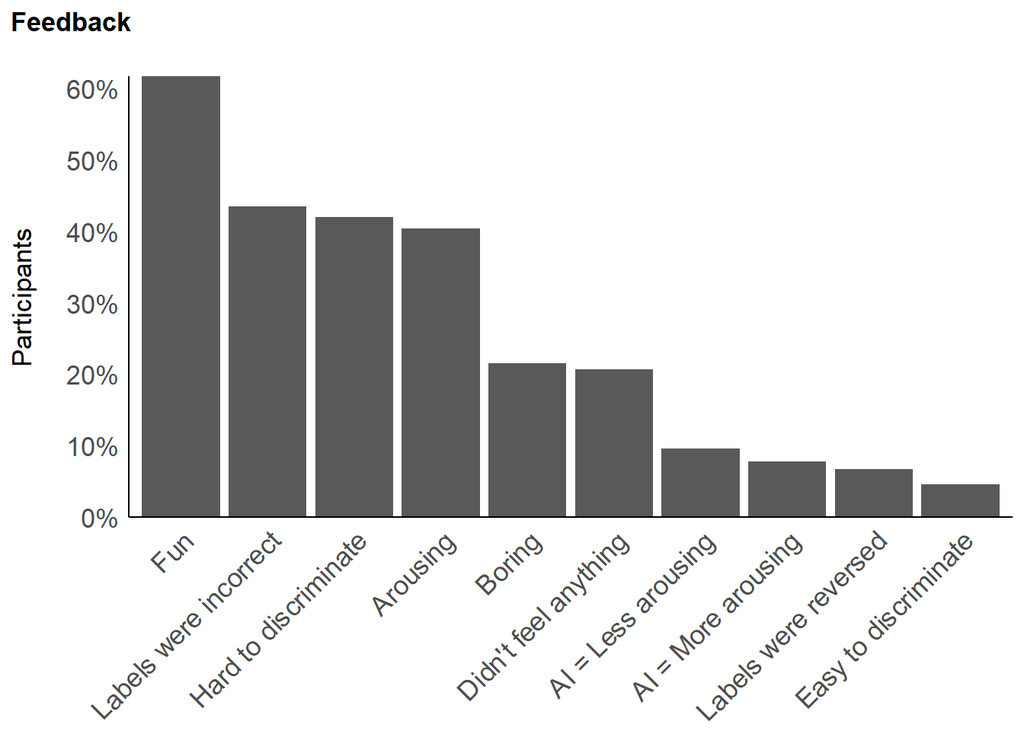

```r
df |>
  select(starts_with("Feedback"), -Feedback_Comments) |>
  pivot_longer(everything(), names_to = "Question", values_to = "Answer") |>
  group_by(Question, Answer) |>
  summarise(prop = n()/nrow(df), .groups = 'drop') |>
  complete(Question, Answer, fill = list(prop = 0)) |>
  filter(Answer == "True") |>
  mutate(Question = str_remove(Question, "Feedback_"),
         Question = str_replace(Question, "AILessArousing", "AI = Less arousing"),
         Question = str_replace(Question, "AIMoreArousing", "AI = More arousing"),
         Question = str_replace(Question, "CouldNotDiscriminate", "Hard to discriminate"),
         Question = str_replace(Question, "LabelsIncorrect", "Labels were incorrect"),
         Question = str_replace(Question, "NoFeels", "Didn't feel anything"),
         Question = str_replace(Question, "CouldDiscriminate", "Easy to discriminate"),
         Question = str_replace(Question, "LabelsReversed", "Labels were reversed")) |>
  mutate(Question = fct_reorder(Question, desc(prop))) |>
  ggplot(aes(x = Question, y = prop)) +
  geom_bar(stat = "identity") +
  scale_y_continuous(expand = c(0, 0), breaks= scales::pretty_breaks(), labels=scales::percent) +
  labs(x="Feedback", y = "Participants", title = "Feedback") +
  theme_modern(axis.title.space = 15) +
  theme(
    plot.title = element_text(size = rel(1.2), face = "bold", hjust = 0),
    plot.subtitle = element_text(size = rel(1.2), vjust = 7),
    axis.text.y = element_text(size = rel(1.1)),
    axis.text.x = element_text(size = rel(1.1), angle = 45, hjust = 1),
    axis.title.x = element_blank()
  )
```

### Comments

```r
data.frame(Language = df$Language,
           Source = df$Experimenter,
           Comments = trimws(df$Feedback_Comments)) |>
  filter(!Comments %in% c(NA, "No", "Nope", "nope", "None", "na", "n/a", "Non")) |>
  arrange(Language, Source) |>
  gt::gt() |>
  gt::opt_stylize() |>
  gt::opt_interactive(use_compact_mode = TRUE)
```

| Language | Source | Comments |
| --- | --- | --- |
| English | Experimenter2 | It was too long to fill out |
| English | Reddit (other) | Didn't have long enough to really examine the images to see the details that AI often gets wrong. |
| English | Unknown | Sizing of pics wasn't ideal for my phone, they didn't fully show/fit on the screen |
| English | readme | Don't know if it's intentional, but found the label green/red to be reversed on different test tries |
| English | reddit12 | Interesting study! |
| English | reddit12 | I think for better results, the images displayed should be friendly to the participant’s sexual orientation |
| English | reddit12 | The test was a little long. I would have liked if it revealed if any of the photos/AI images were mislabeled intentionally or not at the end or just confirm all the labels were correct at the end. |
| English | reddit12 | Better results might be achieved by focusing on themes: Arousal/Enticement (with hetero/homo/bi selected first), and Realism (with unlabeled images and a mix of obvious and no-so-obvious images) |
| English | reddit12 | Less men |
| English | reddit12 | Sliders would have better UX if you could near clicks outside slider would still set the slider value |

[output cut: 74 more lines]

## Exclusion

```r
outliers <- c(
  # "S344"  # Negative Arousal-Valence correlations
  )
potentials <- list()
```

### Mobile

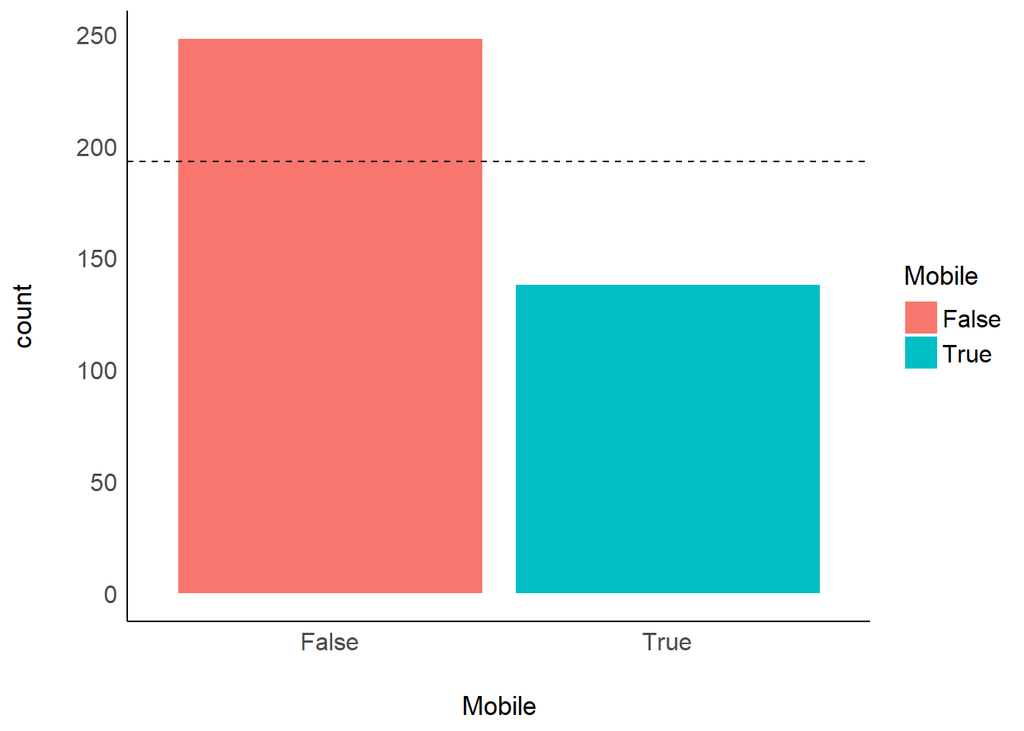

```r
df |>
  ggplot(aes(x=Mobile, fill=Mobile)) +
  geom_bar() +
  geom_hline(yintercept=0.5*nrow(df), linetype="dashed") +
  theme_modern()
```

We removed 138 participants that participated with a mobile device.

```r
df <- filter(df, Mobile == "False")
dftask <- filter(dftask, Participant %in% df$Participant)
```

### Experiment Duration

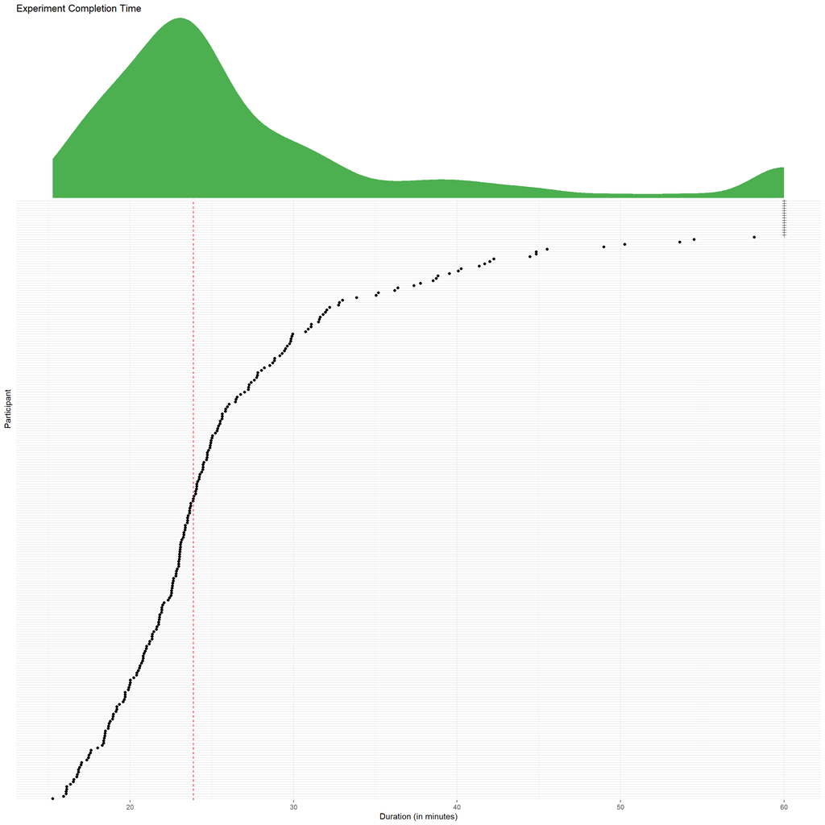

```r
df |>
  mutate(Participant = fct_reorder(Participant, Experiment_Duration),
         Category = ifelse(Experiment_Duration > 60, "extra", "ok"),
         Duration = ifelse(Experiment_Duration > 60, 60, Experiment_Duration),
         Group = ifelse(Participant %in% outliers, "Outlier", "ok")) |>
  ggplot(aes(y = Participant, x = Duration)) +
  geom_point(aes(color = Group, shape = Category)) +
  geom_vline(xintercept = median(df$Experiment_Duration), color = "red", linetype = "dashed") +
  scale_shape_manual(values = c("extra" = 3, ok = 19)) +
  scale_color_manual(values = c("Outlier" = "red", ok = "black"), guide="none") +
  guides(color = "none", shape = "none") +
  ggside::geom_xsidedensity(fill = "#4CAF50", color=NA) +
  ggside::scale_xsidey_continuous(expand = c(0, 0)) +
  labs(
    title = "Experiment Completion Time",
    x = "Duration (in minutes)",
    y = "Participant"
  )  +
  theme_bw() +
  ggside::theme_ggside_void() +
  theme(ggside.panel.scale = .3,
        panel.border = element_blank(),
        axis.text.y = element_blank(),
        axis.ticks.y = element_blank())
```

```r
potentials$expe_duration <- arrange(df, Experiment_Duration) |>
  select(Participant, Experiment_Duration) |>
  head(5)
```

### Task Duration

```r
plot_hist <- function(dat) {
  dat |>
    mutate(Participant = fct_reorder(Participant, RT1)) |>
    filter(RT1 < 100) |>
    ggplot(aes(x=RT1, fill=Participant)) +
    geom_histogram(bins=140) +
    coord_cartesian(xlim = c(0, 15)) +
    scale_fill_metro_d(guide="none") +
    theme_modern() +
    theme(axis.title.y = element_blank(),
          axis.ticks.y = element_blank(),
          axis.text.y = element_blank(),
          axis.line.y = element_blank()) +
    labs(title = "Distribution of Response Time for each Participant", x="Response time (for 3 scales) per stimuli (s)") +
    facet_wrap(~Participant, ncol=5, scales="free_y")
}
```

**1-60**

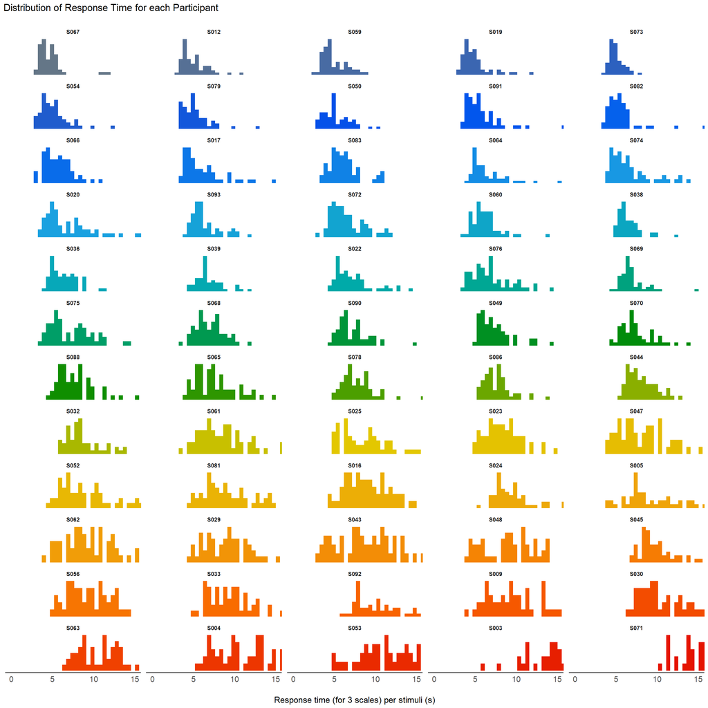

```r
plot_hist(dftask[dftask$Participant %in% df$Participant[1:60], ])
```

**61-120**

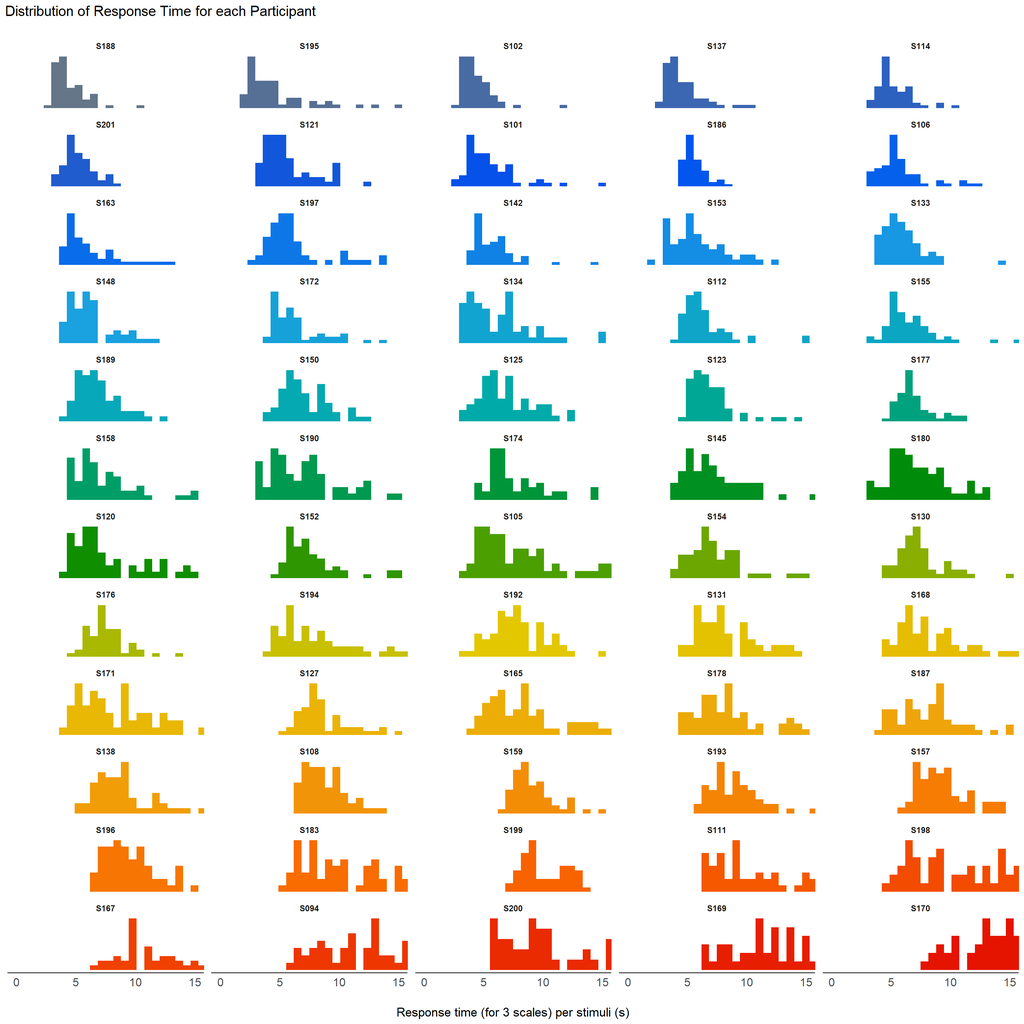

```r
plot_hist(dftask[dftask$Participant %in% df$Participant[61:120], ])
```

**121-180**

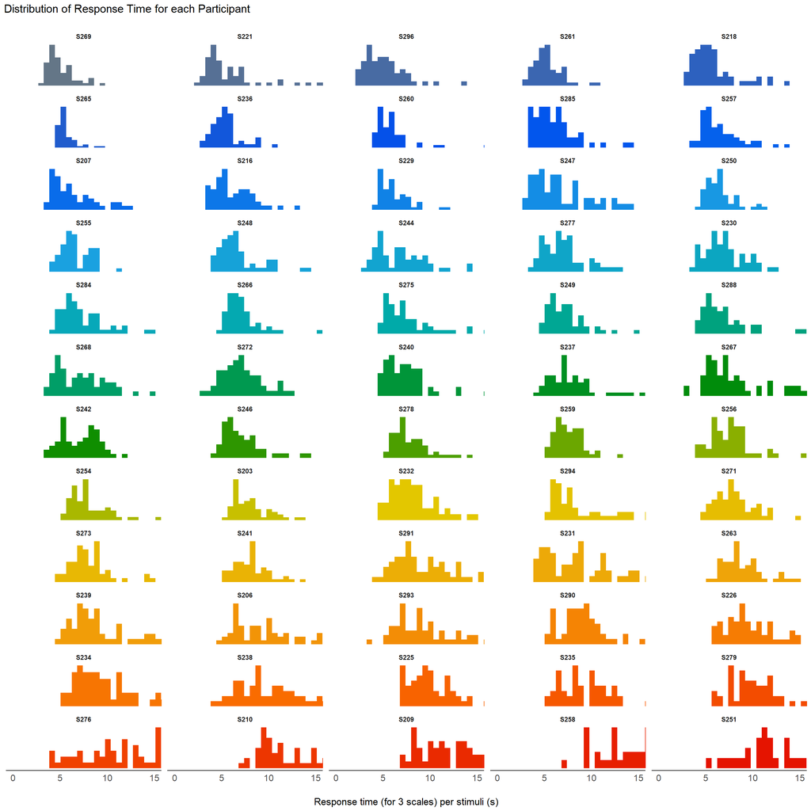

```r
plot_hist(dftask[dftask$Participant %in% df$Participant[121:180], ])
```

### BAIT Questionnaire Duration

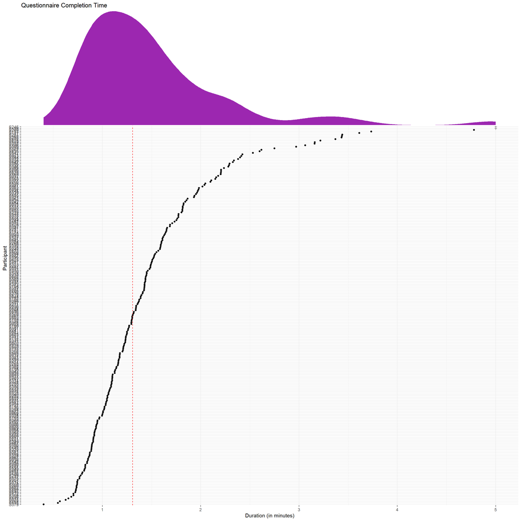

```r
df |>
  mutate(Participant = fct_reorder(Participant, BAIT_Duration),
         Category = ifelse(BAIT_Duration > 5, "extra", "ok"),
         Duration = ifelse(BAIT_Duration > 5, 5, BAIT_Duration),
         Group = ifelse(Participant %in% outliers, "Outlier", "ok")) |>
  ggplot(aes(y = Participant, x = Duration)) +
  geom_point(aes(color = Group, shape = Category)) +
  geom_vline(xintercept = median(df$BAIT_Duration), color = "red", linetype = "dashed") +
  scale_shape_manual(values = c("extra" = 3, ok = 19)) +
  scale_color_manual(values = c("Outlier" = "red", ok = "black"), guide="none") +
  guides(color = "none", shape = "none") +
  ggside::geom_xsidedensity(fill = "#9C27B0", color=NA) +
  ggside::scale_xsidey_continuous(expand = c(0, 0)) +
  labs(
    title = "Questionnaire Completion Time",
    x = "Duration (in minutes)",
    y = "Participant"
  )  +
  theme_bw() +
  ggside::theme_ggside_void() +
  theme(ggside.panel.scale = .3,
        panel.border = element_blank())
```

### Response to Erotic Stimuli

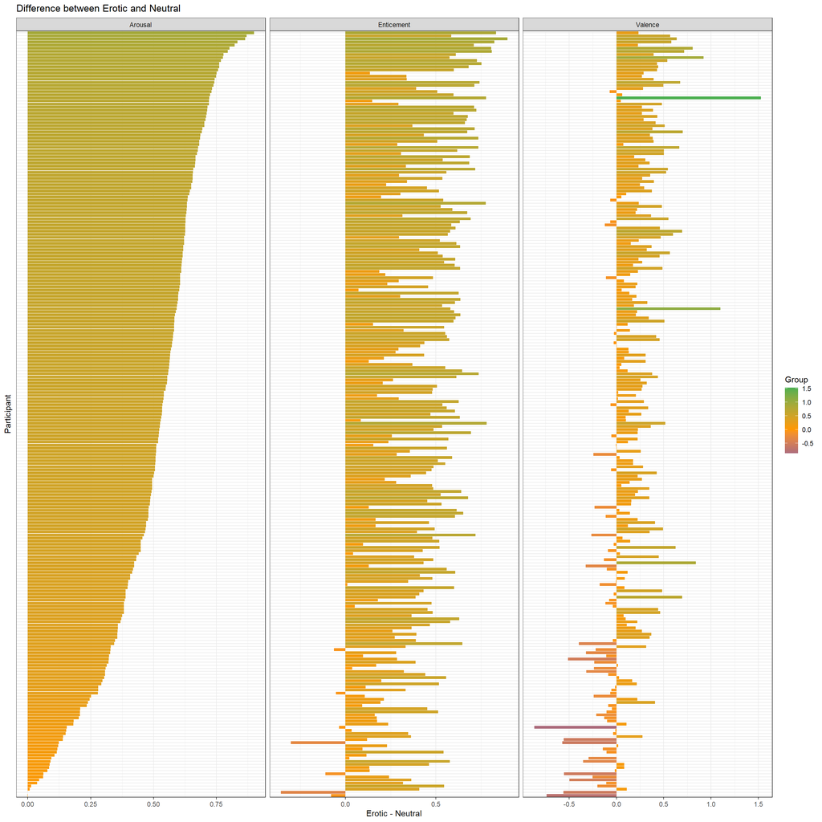

```r
dat <- dftask |>
  filter(Relevance %in% c("Relevant", "Non-erotic")) |>
  group_by(Participant, Type) |>
  summarise(Arousal = mean(Arousal),
            Valence = mean(Valence),
            Enticement = mean(Enticement),
            .groups = "drop") |>
  pivot_wider(names_from = Type, values_from = all_of(c("Arousal", "Valence", "Enticement"))) |>
  transmute(Participant = Participant,
            Arousal = Arousal_Erotic - `Arousal_Non-erotic`,
            Valence = Valence_Erotic - `Valence_Non-erotic`,
            Enticement = Enticement_Erotic - `Enticement_Non-erotic`) |>
  filter(!is.na(Arousal)) |>
  mutate(Participant = fct_reorder(Participant, Arousal))

dat |>
  pivot_longer(-Participant) |>
  mutate(Group = ifelse(Participant %in% outliers, "Outlier", "ok")) |>
  ggplot(aes(x=value, y=Participant, fill=Group)) +
  geom_bar(aes(fill=value), stat = "identity") +
  scale_fill_gradient2(low = "#3F51B5", mid = "#FF9800", high = "#4CAF50", midpoint = 0) +
  # scale_fill_manual(values = c("Outlier" = "red", ok = "black"), guide="none") +
  theme_bw() +
  theme(axis.text.y = element_blank(),
        axis.ticks.y = element_blank()) +
  labs(title = "Difference between Erotic and Neutral", x="Erotic - Neutral") +
  facet_wrap(~name, ncol=3, scales="free_x")
```

```r
potentials$emo_diff <- arrange(dat, Arousal) |>
  head(5)
```

### Response Coherence

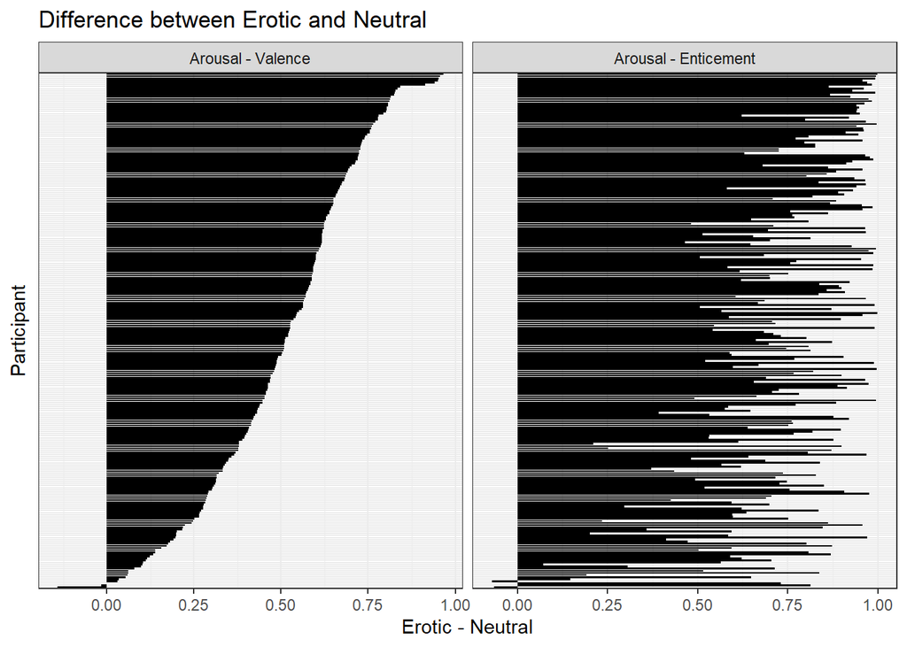

```r
dat <- dftask |>
  summarize(cor_ArVal = cor(Arousal, Valence),
            cor_ArEnt = cor(Arousal, Enticement),
            .by="Participant") |>
  mutate(Participant = fct_reorder(Participant, cor_ArVal))

dat |>
  pivot_longer(-Participant) |>
  mutate(Group = ifelse(Participant %in% outliers, "Outlier", "ok")) |>
  mutate(name = fct_relevel(name, "cor_ArVal", "cor_ArEnt"),
         name = fct_recode(name, "Arousal - Valence" = "cor_ArVal", "Arousal - Enticement" = "cor_ArEnt")) |>
  ggplot(aes(y = Participant, x = value, fill = Group)) +
  geom_bar(stat = "identity") +
  # scale_fill_gradient2(low = "#3F51B5", mid = "#FF9800", high = "#4CAF50", midpoint = 0) +
  scale_fill_manual(values = c("Outlier" = "red", ok = "black"), guide="none") +
  theme_bw() +
  theme(axis.text.y = element_blank(),
        axis.ticks.y = element_blank()) +
  labs(title = "Difference between Erotic and Neutral", x="Erotic - Neutral") +
  facet_wrap(~name, ncol=3, scales="free_x")
```

```r
potentials$emo_cor <- arrange(dat, cor_ArVal) |>
  head(5)
```

```r
c(as.character(potentials$expe_duration$Participant),
  as.character(potentials$emo_diff$Participant),
  as.character(potentials$emo_cor$Participant)) |>
  table()
```

```
S019 S105 S137 S168 S188 S261 S284 S305 S307 S340 S343 S383
   1    1    1    2    1    1    1    1    1    1    2    2
```

### Sexual Profile

#### Sample

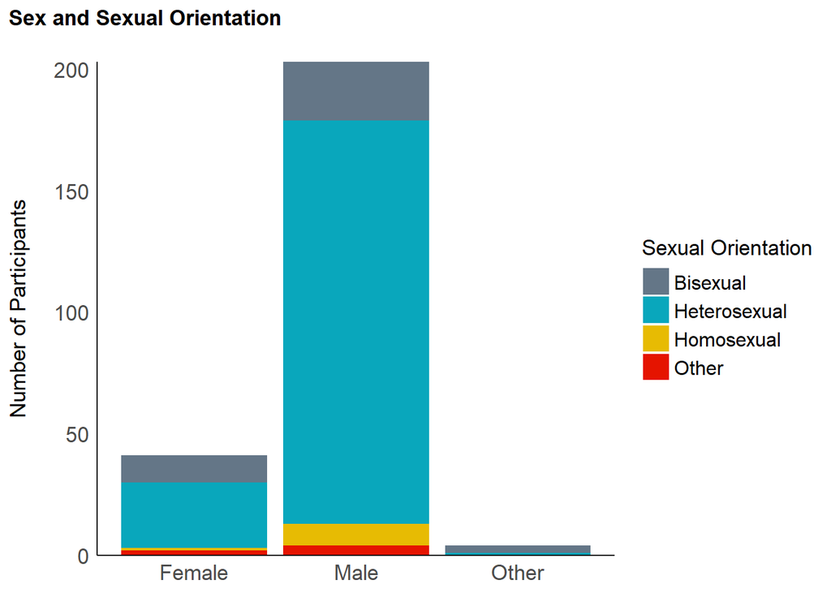

```r
df |>
  ggplot(aes(x = Sex)) +
  geom_bar(aes(fill = SexualOrientation)) +
  scale_y_continuous(expand = c(0, 0), breaks = scales::pretty_breaks()) +
  scale_fill_metro_d() +
  labs(x = "Biological Sex", y = "Number of Participants", title = "Sex and Sexual Orientation", fill = "Sexual Orientation") +
  theme_modern(axis.title.space = 15) +
  theme(
    plot.title = element_text(size = rel(1.2), face = "bold", hjust = 0),
    plot.subtitle = element_text(size = rel(1.2), vjust = 7),
    axis.text.y = element_text(size = rel(1.1)),
    axis.text.x = element_text(size = rel(1.1)),
    axis.title.x = element_blank()
  )
```

We removed 10 participants that were incompatible with further analysis.

```r
df <- filter(df, Sex != "Other" & SexualOrientation != "Other")
dftask <- filter(dftask, Participant %in% df$Participant)
```

#### Task Behaviour

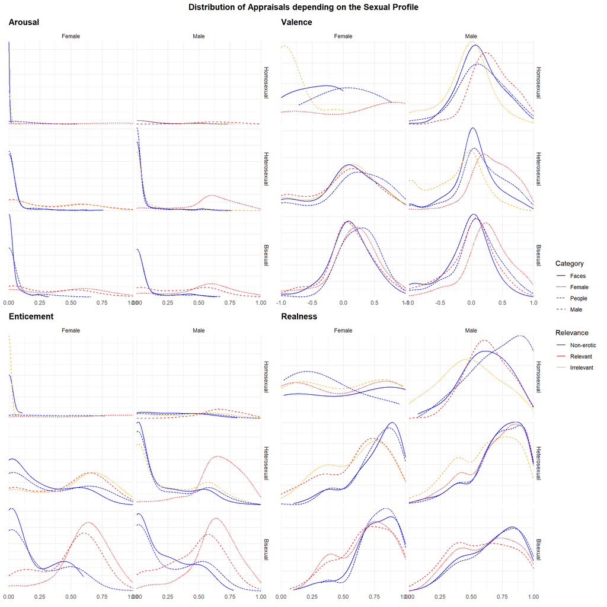

```r
show_distribution <- function(dftask, target="Arousal") {
  dftask |>
    filter(SexualOrientation %in% c("Heterosexual", "Bisexual", "Homosexual")) |>
    bayestestR::estimate_density(select=target,
                                 at=c("Relevance", "Category", "Sex", "SexualOrientation"),
                                 method="KernSmooth") |>
    ggplot(aes(x = x, y = y)) +
    geom_line(aes(color = Relevance, linetype = Category)) +
    facet_grid(SexualOrientation~Sex, scales="free_y")  +
    scale_color_manual(values = c("Relevant" = "red", "Non-erotic" = "blue", "Irrelevant"="orange")) +
    scale_y_continuous(expand = c(0, 0)) +
    scale_x_continuous(expand = c(0, 0)) +
    theme_minimal()  +
    theme(axis.title.x = element_blank(),
          axis.title.y = element_blank(),
          axis.text.y = element_blank(),
          plot.title = element_text(face="bold")) +
    labs(title = target)
}

(show_distribution(dftask, "Arousal") | show_distribution(dftask, "Valence")) /
  (show_distribution(dftask, "Enticement") | show_distribution(dftask, "Realness")) +
  patchwork::plot_layout(guides = "collect") +
  patchwork::plot_annotation(title = "Distribution of Appraisals depending on the Sexual Profile",
                             theme = theme(plot.title = element_text(hjust = 0.5, face="bold")))
```

We kept only heterosexual participants (81.09%).

```r
df <- filter(df, SexualOrientation == "Heterosexual")
dftask <- filter(dftask, Participant %in% df$Participant)
```

## Final Sample

```r
df <- filter(df, !Participant %in% outliers)
dftask <- filter(dftask, Participant %in% df$Participant)
```

**Summary**

The final sample includes 193 participants (Mean age = 37.4, SD = 12.9, range: [18, 80]; Sex: 14.0% females, 86.0% males, 0.0% other; Education: Bachelor, 36.79%; Doctorate, 7.77%; High School, 19.69%; Master, 33.16%; Other, 1.55%; Primary School, 0.52%; Università (laurea magistrale) o equivalente, 0.52%; Country: 29.02% USA, 14.51% France, 11.92% UK, 44.56% other).

**Origin**

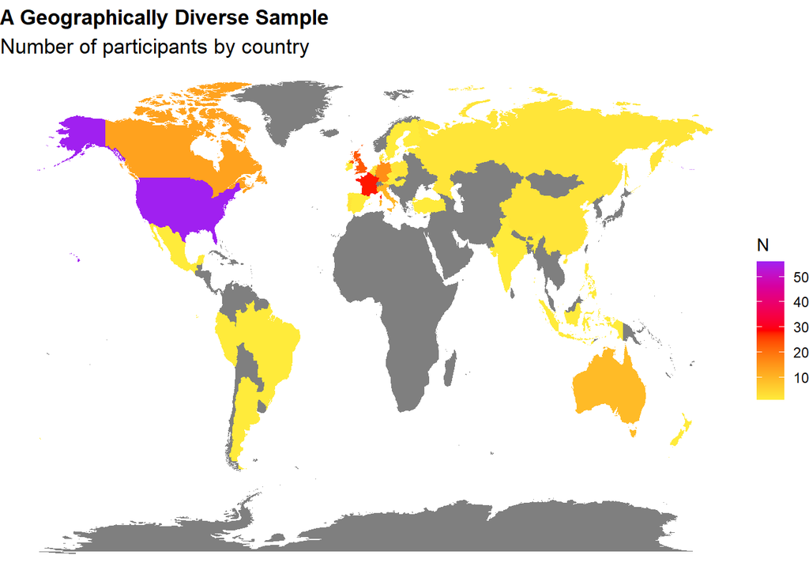

```r
p_country <- dplyr::select(df, region = Country) |>
  group_by(region) |>
  summarize(n = n()) |>
  right_join(map_data("world"), by = "region") |>
  ggplot(aes(long, lat, group = group)) +
  geom_polygon(aes(fill = n)) +
  scale_fill_gradientn(colors = c("#FFEB3B", "red", "purple")) +
  labs(fill = "N") +
  theme_void() +
  labs(title = "A Geographically Diverse Sample", subtitle = "Number of participants by country")  +
  theme(
    plot.title = element_text(size = rel(1.2), face = "bold", hjust = 0),
    plot.subtitle = element_text(size = rel(1.2))
  )
p_country
```

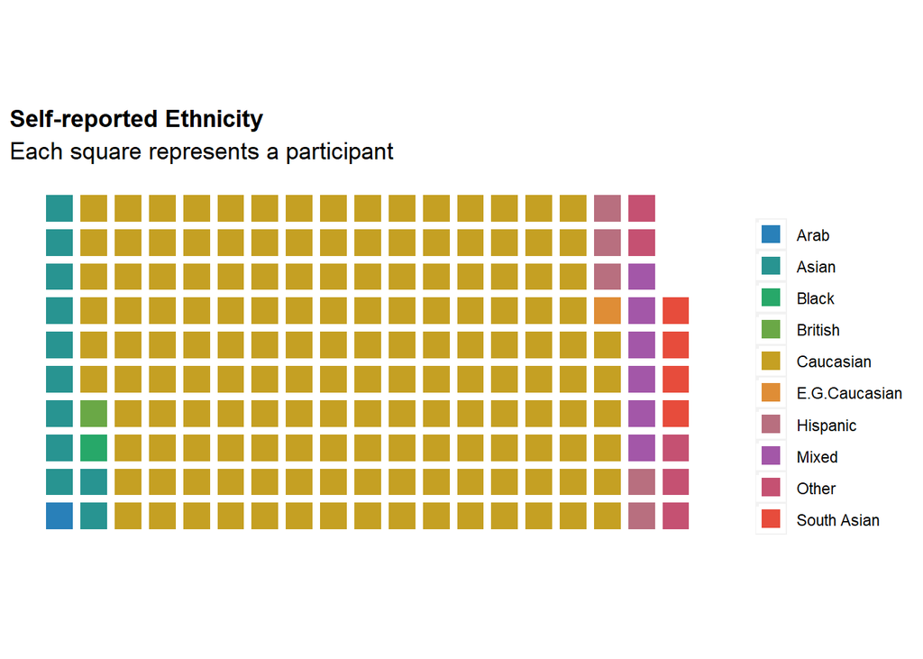

```r
ggwaffle::waffle_iron(df, ggwaffle::aes_d(group = Ethnicity), rows=10) |>
  ggplot(aes(x, y, fill = group)) +
  ggwaffle::geom_waffle() +
  coord_equal() +
  scale_fill_flat_d() +
  ggwaffle::theme_waffle() +
  labs(title = "Self-reported Ethnicity", subtitle = "Each square represents a participant", fill="")  +
  theme(
    plot.title = element_text(size = rel(1.2), face = "bold", hjust = 0),
    plot.subtitle = element_text(size = rel(1.2)),
    axis.title.x = element_blank(),
    axis.title.y = element_blank()
  )
```

**Age**

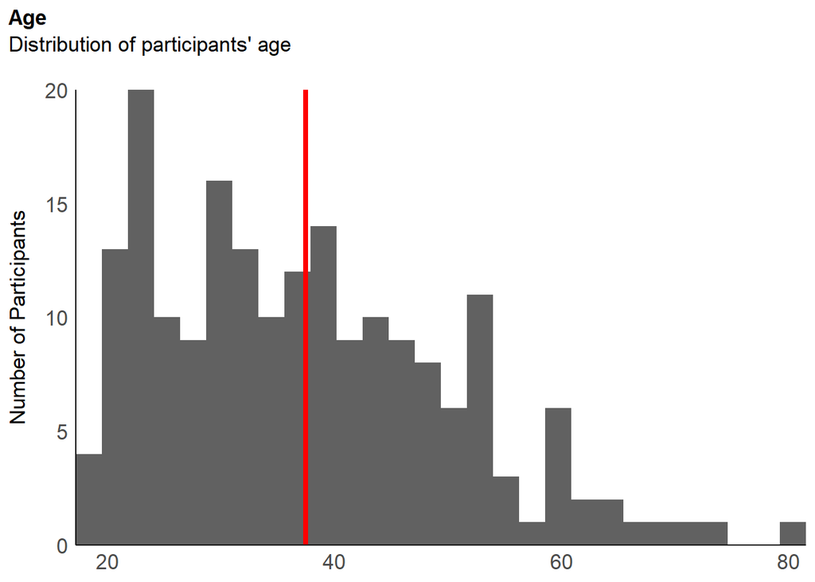

```r
p_age <- estimate_density(df$Age) |>
  normalize(select = y) |>
  mutate(y = y * 86) |>  # To match the binwidth
  ggplot(aes(x = x)) +
  geom_histogram(data=df, aes(x = Age), fill = "#616161", bins=28) +
  # geom_line(aes(y = y), color = "orange", linewidth=2) +
  geom_vline(xintercept = mean(df$Age), color = "red", linewidth=1.5) +
  # geom_label(data = data.frame(x = mean(df$Age) * 1.15, y = 0.95 * 75), aes(y = y), color = "red", label = paste0("Mean = ", format_value(mean(df$Age)))) +
  scale_x_continuous(expand = c(0, 0)) +
  scale_y_continuous(expand = c(0, 0)) +
  labs(title = "Age", y = "Number of Participants", color = NULL, subtitle = "Distribution of participants' age") +
  theme_modern(axis.title.space = 10) +
  theme(
    plot.title = element_text(size = rel(1.2), face = "bold", hjust = 0),
    plot.subtitle = element_text(size = rel(1.2), vjust = 7),
    axis.text.y = element_text(size = rel(1.1)),
    axis.text.x = element_text(size = rel(1.1)),
    axis.title.x = element_blank()
  )
p_age
```

**Education**

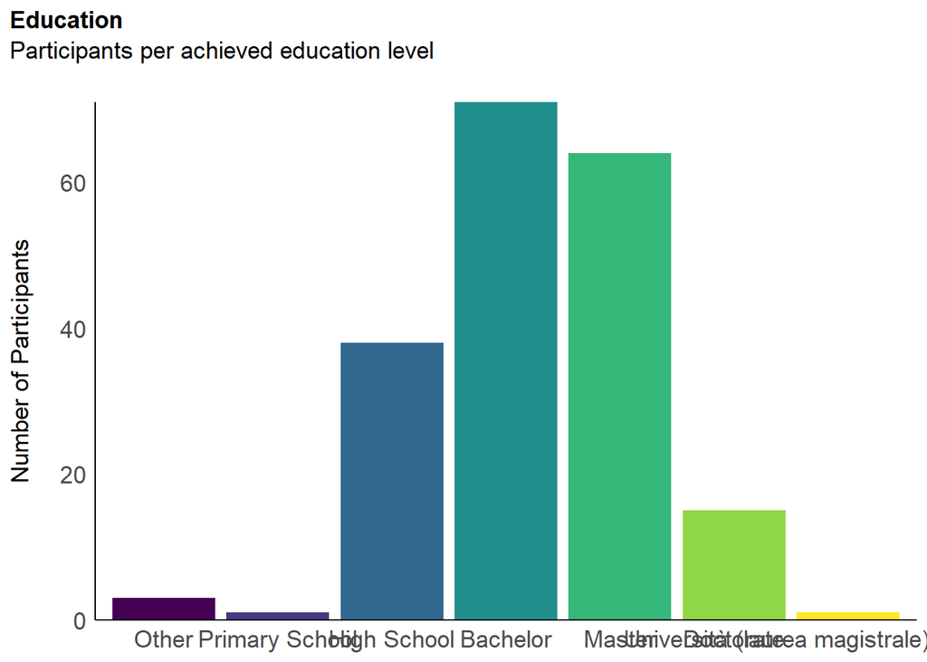

```r
p_edu <- df |>
  mutate(Education = fct_relevel(Education, "Other", "Primary School", "High School", "Bachelor", "Master", "Doctorate")) |>
  ggplot(aes(x = Education)) +
  geom_bar(aes(fill = Education)) +
  scale_y_continuous(expand = c(0, 0), breaks= scales::pretty_breaks()) +
  scale_fill_viridis_d(guide = "none") +
  labs(title = "Education", y = "Number of Participants", subtitle = "Participants per achieved education level") +
  theme_modern(axis.title.space = 15) +
  theme(
    plot.title = element_text(size = rel(1.2), face = "bold", hjust = 0),
    plot.subtitle = element_text(size = rel(1.2), vjust = 7),
    axis.text.y = element_text(size = rel(1.1)),
    axis.text.x = element_text(size = rel(1.1)),
    axis.title.x = element_blank()
  )
p_edu
```

**Sex**

#### Birth Control

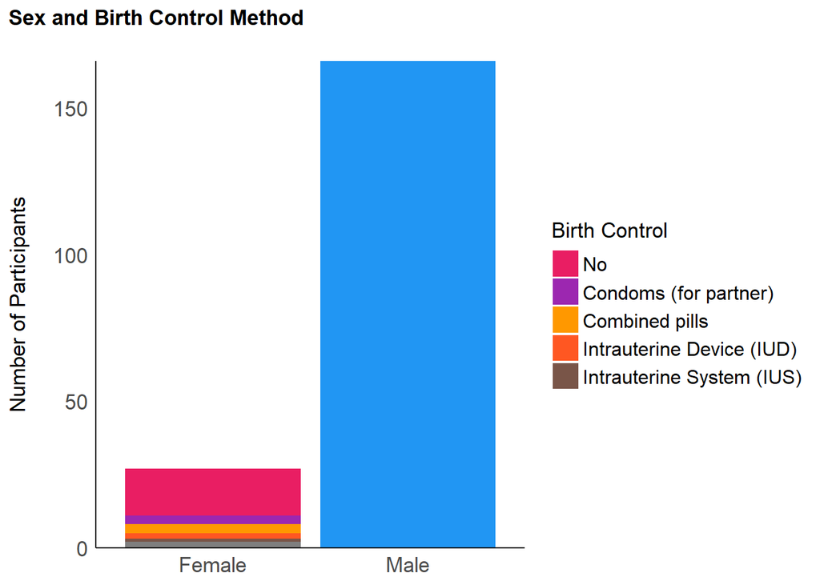

```r
colors <- c(
  "NA" = "#2196F3", "No" = "#E91E63", "Condoms (for partner)" = "#9C27B0",
  "Combined pills" = "#FF9800", "Intrauterine Device (IUD)" = "#FF5722",
  "Intrauterine System (IUS)" = "#795548"
)
colors <- colors[names(colors) %in% c("NA", df$BirthControl)]

p_sex <- df |>
  mutate(BirthControl = ifelse(Sex == "Male", "NA", BirthControl),
         BirthControl = fct_relevel(BirthControl, names(colors))) |>
  ggplot(aes(x = Sex)) +
  geom_bar(aes(fill = BirthControl)) +
  scale_y_continuous(expand = c(0, 0), breaks = scales::pretty_breaks()) +
  scale_fill_manual(
    values = colors,
    breaks = names(colors)[2:length(colors)]
  ) +
  labs(x = "Biological Sex", y = "Number of Participants", title = "Sex and Birth Control Method", fill = "Birth Control") +
  theme_modern(axis.title.space = 15) +
  theme(
    plot.title = element_text(size = rel(1.2), face = "bold", hjust = 0),
    plot.subtitle = element_text(size = rel(1.2), vjust = 7),
    axis.text.y = element_text(size = rel(1.1)),
    axis.text.x = element_text(size = rel(1.1)),
    axis.title.x = element_blank()
  )
p_sex
```

#### Sexual Profile

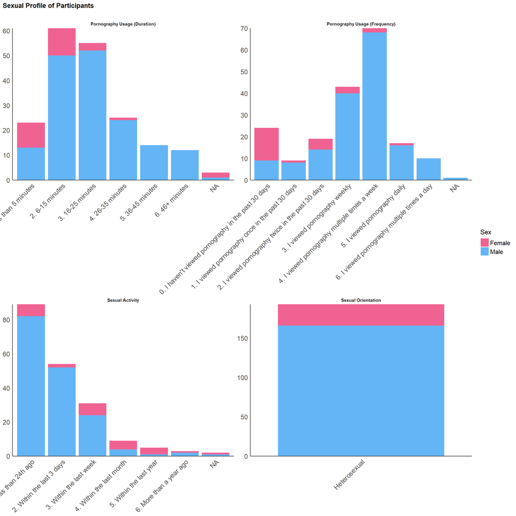

```r
p_sexprofile <- df |>
  select(Participant, Sex, SexualOrientation, SexualActivity, COPS_Duration_1, COPS_Frequency_2) |>
  pivot_longer(-all_of(c("Participant", "Sex"))) |>
  mutate(name = str_replace_all(name, "SexualOrientation", "Sexual Orientation"),
         name = str_replace_all(name, "SexualActivity", "Sexual Activity"),
         name = str_replace_all(name, "COPS_Duration_1", "Pornography Usage (Duration)"),
         name = str_replace_all(name, "COPS_Frequency_2", "Pornography Usage (Frequency)")) |>
  ggplot(aes(x = value, fill=Sex)) +
  geom_bar() +
  scale_y_continuous(expand = c(0, 0), breaks= scales::pretty_breaks()) +
  scale_fill_manual(values = c("Male"= "#64B5F6", "Female"= "#F06292")) +
  labs(title = "Sexual Profile of Participants") +
  theme_modern(axis.title.space = 15) +
  theme(
    plot.title = element_text(size = rel(1.2), face = "bold", hjust = 0),
    plot.subtitle = element_text(size = rel(1.2), vjust = 7),
    axis.text.y = element_text(size = rel(1.1)),
    axis.text.x = element_text(size = rel(1.1), angle = 45, hjust = 1),
    axis.title.x = element_blank(),
    axis.title.y = element_blank()
  ) +
  facet_wrap(~name, scales = "free")
p_sexprofile
```

**Expertise**

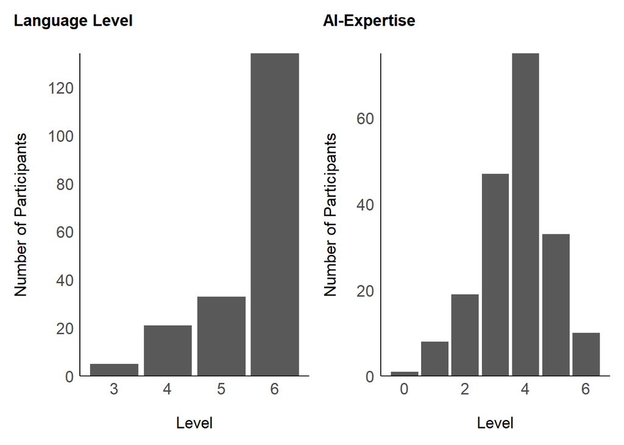

```r
p_language <- df |>
  ggplot(aes(x = Language_Level)) +
  geom_bar() +
  scale_y_continuous(expand = c(0, 0), breaks= scales::pretty_breaks()) +
  labs(x = "Level", y = "Number of Participants", title = "Language Level") +
  theme_modern(axis.title.space = 15) +
  theme(
    plot.title = element_text(size = rel(1.2), face = "bold", hjust = 0),
    plot.subtitle = element_text(size = rel(1.2), vjust = 7),
    axis.text.y = element_text(size = rel(1.1)),
    axis.text.x = element_text(size = rel(1.1))
  )

p_expertise <- df |>
  ggplot(aes(x = AI_Knowledge)) +
  geom_bar() +
  scale_y_continuous(expand = c(0, 0), breaks= scales::pretty_breaks()) +
  labs(x = "Level", y = "Number of Participants", title = "AI-Expertise") +
  theme_modern(axis.title.space = 15) +
  theme(
    plot.title = element_text(size = rel(1.2), face = "bold", hjust = 0),
    plot.subtitle = element_text(size = rel(1.2), vjust = 7),
    axis.text.y = element_text(size = rel(1.1)),
    axis.text.x = element_text(size = rel(1.1))
  )

p_language | p_expertise
```

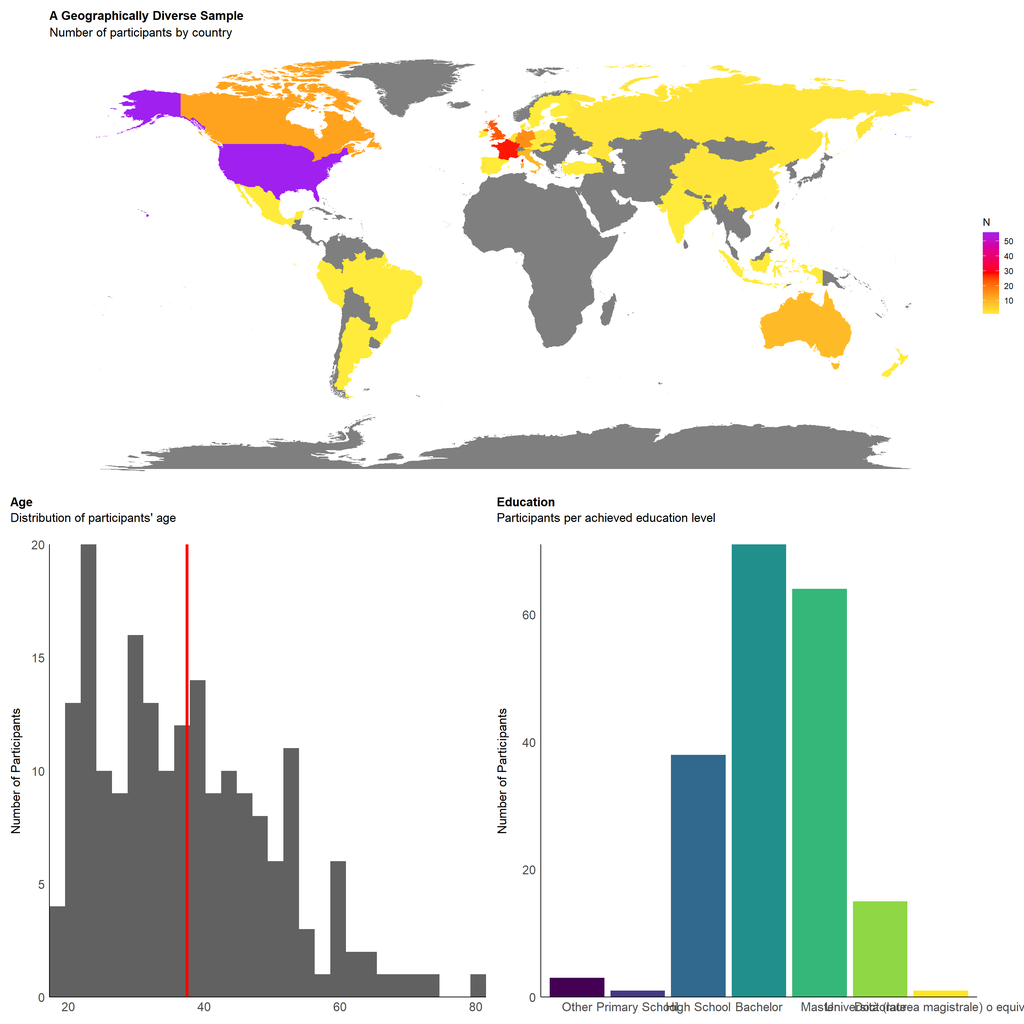

```r
p_country /
  (p_age + p_edu)
```

## Beliefs about Artificial Information Technology (BAIT)

This section pertains to the validation of the BAIT scale measuring beliefs and expectations about artificial creations.

**Structure**

#### Exploratory Factor Analysis

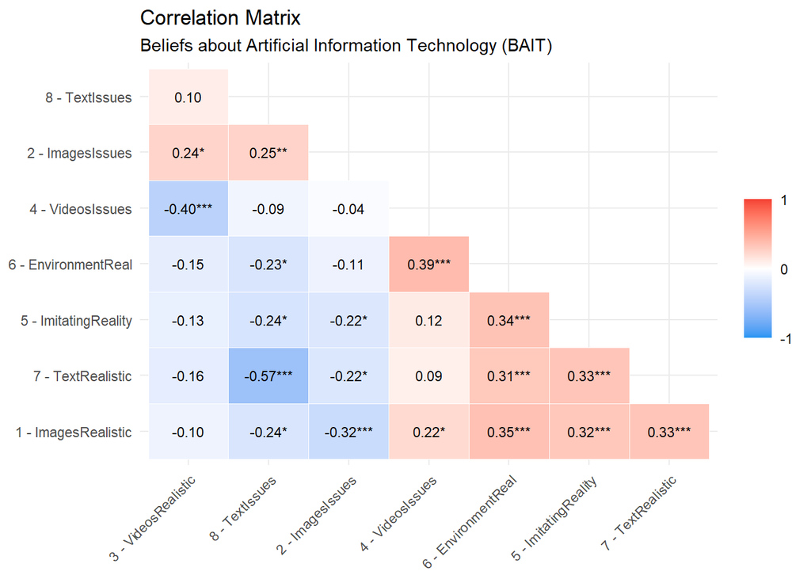

```r
bait <- df |>
  select(starts_with("BAIT_"), -BAIT_Duration)


cor <- correlation::correlation(bait, redundant = TRUE) |>
  correlation::cor_sort() |>
  correlation::cor_lower()

clean_labels <- function(x) {
  x <- str_remove_all(x, "BAIT_") |>
    str_replace_all("_", " - ")
}

cor |>
  mutate(val = paste0(insight::format_value(r), format_p(p, stars_only=TRUE))) |>
  mutate(Parameter2 = fct_rev(Parameter2)) |>
  mutate(Parameter1 = fct_relabel(Parameter1, clean_labels),
         Parameter2 = fct_relabel(Parameter2, clean_labels)) |>
  ggplot(aes(x=Parameter1, y=Parameter2)) +
  geom_tile(aes(fill = r), color = "white") +
  geom_text(aes(label = val), size = 3) +
  labs(title = "Correlation Matrix",
       subtitle = "Beliefs about Artificial Information Technology (BAIT)") +
  scale_fill_gradient2(
    low = "#2196F3",
    mid = "white",
    high = "#F44336",
    breaks = c(-1, 0, 1),
    guide = guide_colourbar(ticks=FALSE),
    midpoint = 0,
    na.value = "grey85",
    limit = c(-1, 1))  +
  theme_minimal() +
  theme(legend.title = element_blank(),
        axis.title.x = element_blank(),
        axis.title.y = element_blank(),
        axis.text.x = element_text(angle = 45, hjust = 1))
```

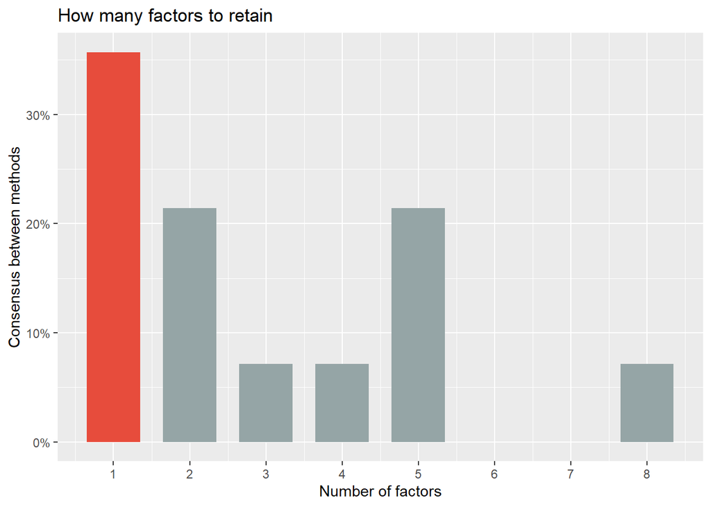

```r
n <- parameters::n_factors(bait, package = "nFactors")
plot(n)
```

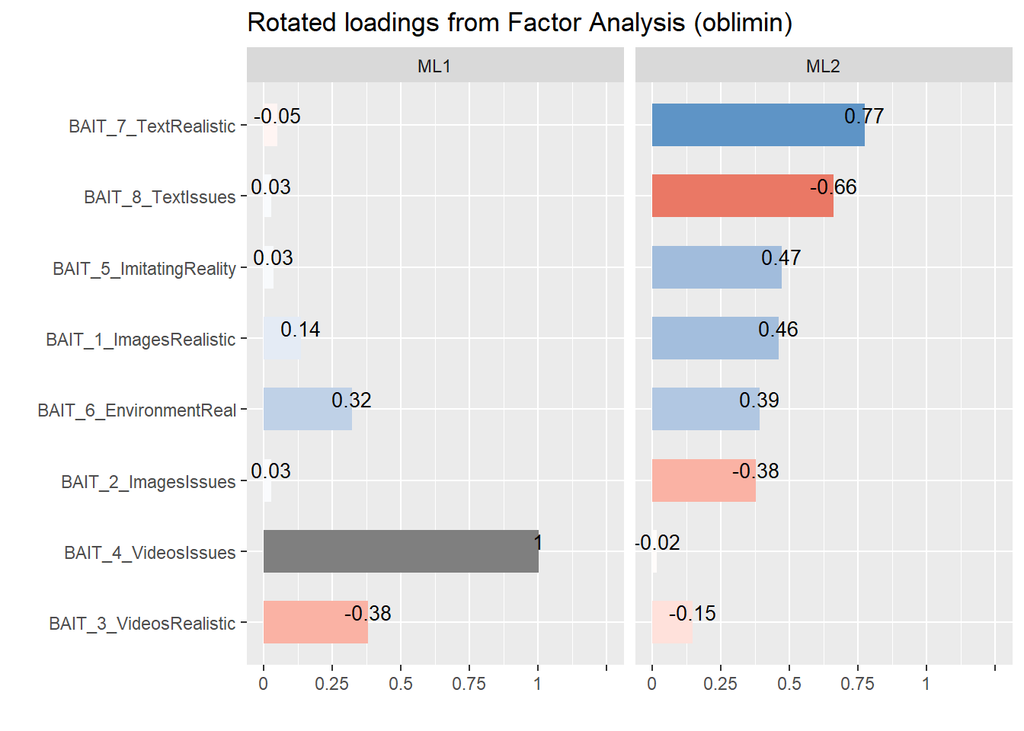

```r
efa <- parameters::factor_analysis(bait, cor=cor(bait), n=2, rotation = "oblimin", sort=TRUE, scores="tenBerge", fm="ml")
plot(efa)
```

```r
display(efa)
```

Rotated loadings from Factor Analysis (oblimin-rotation)

| Variable | ML2 | ML1 | Complexity | Uniqueness |
| --- | --- | --- | --- | --- |
| BAIT_7_TextRealistic | 0.77 | -0.05 | 1.01 | 0.41 |
| BAIT_8_TextIssues | -0.66 | 0.03 | 1.00 | 0.57 |
| BAIT_5_ImitatingReality | 0.47 | 0.03 | 1.01 | 0.77 |
| BAIT_1_ImagesRealistic | 0.46 | 0.14 | 1.17 | 0.74 |
| BAIT_6_EnvironmentReal | 0.39 | 0.32 | 1.93 | 0.70 |
| BAIT_2_ImagesIssues | -0.38 | 0.03 | 1.01 | 0.86 |
| BAIT_4_VideosIssues | -0.02 | 1.00 | 1.00 | 5.00e-03 |
| BAIT_3_VideosRealistic | -0.15 | -0.38 | 1.29 | 0.81 |

The 2 latent factors (oblimin rotation) accounted for 39.10% of the total variance of the original data (ML2 = 22.77%, ML1 = 16.32%).

#### Confirmatory Factor Analysis

```r
m1 <- lavaan::cfa(efa_to_cfa(efa, threshold="max"), data=df)
m2 <- lavaan::cfa(
  "G =~ BAIT_5_ImitatingReality + BAIT_6_EnvironmentReal + BAIT_4_VideosIssues + BAIT_8_TextIssues + BAIT_3_VideosRealistic + BAIT_1_ImagesRealistic + BAIT_2_ImagesIssues + BAIT_7_TextRealistic",
  data=df)

# bayestestR::bayesfactor_models(m1, m2)
lavaan::anova(m1, m2)
```

```
Chi-Squared Difference Test

   Df     AIC      BIC  Chisq Chisq diff   RMSEA Df diff Pr(>Chisq)
m1 19 -80.519 -25.0533 71.674
m2 20 -56.292  -4.0887 97.901     26.227 0.36154       1  3.035e-07 ***
---
Signif. codes:  0 '***' 0.001 '**' 0.01 '*' 0.05 '.' 0.1 ' ' 1
```

```r
display(parameters::parameters(m1))
```

# Loading

| Link | Coefficient | SE | 95% CI | z | p |
| --- | --- | --- | --- | --- | --- |
| ML2 =~ BAIT_7_TextRealistic | 1.00 | 0.00 | (1.00, 1.00) |  | < .001 |
| ML2 =~ BAIT_5_ImitatingReality | 0.74 | 0.13 | (0.48, 1.00) | 5.64 | < .001 |
| ML2 =~ BAIT_8_TextIssues | -0.84 | 0.13 | (-1.09, -0.59) | -6.58 | < .001 |
| ML2 =~ BAIT_1_ImagesRealistic | 0.50 | 0.09 | (0.33, 0.67) | 5.88 | < .001 |
| ML2 =~ BAIT_6_EnvironmentReal | 0.68 | 0.12 | (0.44, 0.92) | 5.65 | < .001 |
| ML2 =~ BAIT_2_ImagesIssues | -0.48 | 0.11 | (-0.69, -0.27) | -4.44 | < .001 |
| ML1 =~ BAIT_3_VideosRealistic | 1.00 | 0.00 | (1.00, 1.00) |  | < .001 |
| ML1 =~ BAIT_4_VideosIssues | -1.04 | 0.38 | (-1.78, -0.30) | -2.74 | 0.006 |

# Correlation

| Link | Coefficient | SE | 95% CI | z | p |
| --- | --- | --- | --- | --- | --- |
| ML2 ~~ ML1 | -0.01 | 4.45e-03 | (-0.02, -3.83e-03) | -2.82 | 0.005 |

**Scores**

```r
# Merge with data
scores <- lavaan::predict(m1) |>
  as.data.frame() |>
  data_rename(c("ML2"), c("BAIT_SEM")) |>
  mutate(Participant = df$Participant) |>
  mutate(BAIT = rowMeans(select(bait, -contains("Videos")), na.rm = TRUE))

df <- full_join(df, scores[c("Participant", "BAIT_SEM", "BAIT")], by="Participant")
```

We computed two type of general scores for the BAIT scale, an **empirical** score based on the average of observed data (of the most loading items) and a **model-based** score as predicted by the structural model. The first one gives equal weight to all items (and keeps the same [0-1] range), while the second one is based on the factor loadings and the covariance structure.

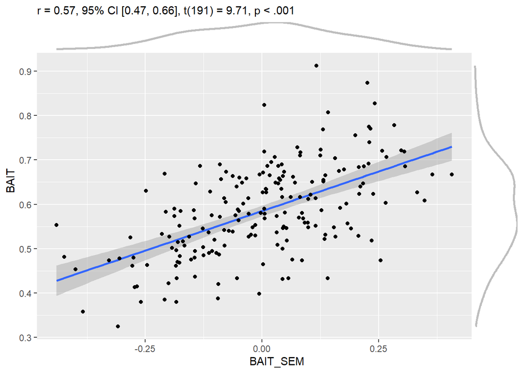

```r
correlation::cor_test(scores, "BAIT_SEM", "BAIT") |>
  plot() +
  ggside::geom_xsidedensity(aes(x=BAIT_SEM), color="grey", linewidth=1) +
  ggside::geom_ysidedensity(aes(y=BAIT), color="grey", linewidth=1) +
  ggside::scale_xsidey_continuous(expand = c(0, 0)) +
  ggside::scale_ysidex_continuous(expand = c(0, 0)) +
  ggside::theme_ggside_void() +
  theme(ggside.panel.scale = .1)
```

**Validity**

#### Corrrelation with GAAIS

```r
table <- correlation::correlation(scores,
                         select(df, starts_with("GAAIS")),
                         bayesian=TRUE) |>
  summary()

format(table) |>
  datawizard::data_rename("Parameter", "Variables") |>
  gt::gt() |>
  gt::cols_align(align="center") |>
  gt::tab_options(column_labels.font.weight="bold")
```

| Variables | GAAIS_Positive_17 | GAAIS_Positive_12 | GAAIS_Positive_7 | GAAIS_Negative_9 | GAAIS_Negative_10 | GAAIS_Negative_15 |
| --- | --- | --- | --- | --- | --- | --- |
| BAIT_SEM | 0.23*** | 0.23*** | 0.28*** | 0.12 | -0.14* | -0.11 |
| ML1 | -9.43e-03 | 0.06 | 0.06 | -0.12 | -0.06 | -0.17** |
| BAIT | 0.24*** | 0.11 | 0.09 | 0.12 | 8.47e-03 | 0.01 |

#### AI-Expertise

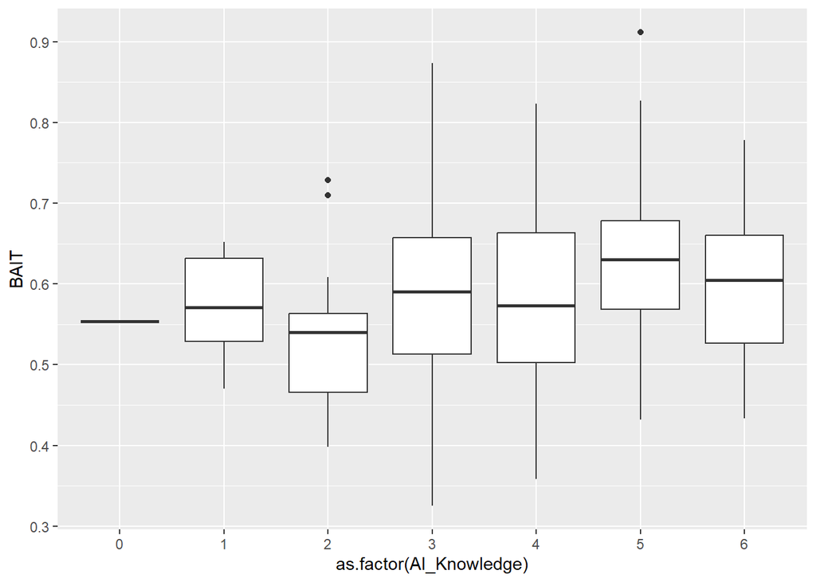

```r
df |>
  ggplot(aes(x=as.factor(AI_Knowledge), y=BAIT)) +
  geom_boxplot()
```

```r
# m <- betareg::betareg(BAIT ~ AI_Knowledge, data=df)
m <- lm(BAIT_SEM ~ AI_Knowledge, data=df)
# m <- brms::brm(BAIT ~ mo(AI_Knowledge), data=dfsub, algorithm = "meanfield")
# m <- brms::brm(BAIT ~ AI_Knowledge, data=dfsub, algorithm = "meanfield")
display(parameters::parameters(m))
```

| Parameter | Coefficient | SE | 95% CI | t(191) | p |
| --- | --- | --- | --- | --- | --- |
| (Intercept) | -0.03 | 0.04 | (-0.11, 0.04) | -0.88 | 0.379 |
| AI Knowledge | 9.44e-03 | 0.01 | (-0.01, 0.03) | 0.93 | 0.356 |

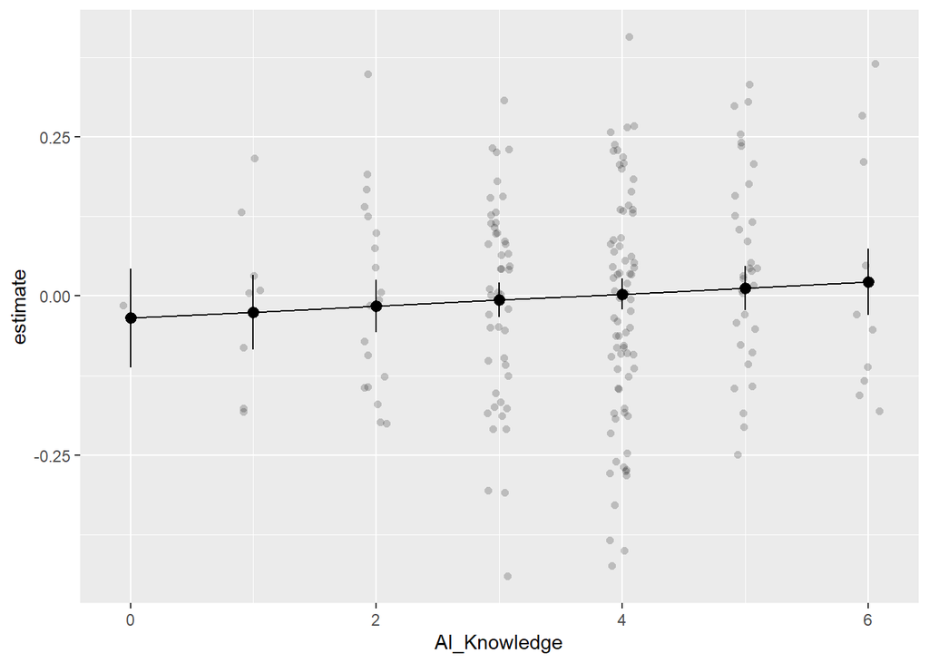

```r
marginaleffects::predictions(m, by=c("AI_Knowledge"), newdata = "marginalmeans") |>
  as.data.frame() |>
  ggplot(aes(x=AI_Knowledge, y=estimate)) +
  geom_jitter2(data=df, aes(y=BAIT_SEM), alpha=0.2, width=0.1) +
  geom_line(aes(group=1), position = position_dodge(width=0.2)) +
  geom_pointrange(aes(ymin = conf.low, ymax=conf.high), position = position_dodge(width=0.2))
```

#### Gender and Age

```r
# m <- betareg::betareg(BAIT ~ Sex / Age, data=df, na.action=na.omit)
m <- lm(BAIT_SEM ~ Sex / Age, data=df)
display(parameters::parameters(m))
```

| Parameter | Coefficient | SE | 95% CI | t(189) | p |
| --- | --- | --- | --- | --- | --- |
| (Intercept) | 0.04 | 0.10 | (-0.15, 0.23) | 0.38 | 0.703 |
| Sex (Male) | -0.03 | 0.11 | (-0.24, 0.18) | -0.29 | 0.770 |
| Sex (Female) × Age | -4.84e-04 | 3.19e-03 | (-6.77e-03, 5.80e-03) | -0.15 | 0.879 |
| Sex (Male) × Age | -2.55e-04 | 1.02e-03 | (-2.27e-03, 1.76e-03) | -0.25 | 0.804 |

#### Belief in the Instructions

```r
glm(Feedback_LabelsIncorrect ~ BAIT_SEM * AI_Knowledge,
    data=mutate(df, Feedback_LabelsIncorrect = ifelse(Feedback_LabelsIncorrect=="True", 1, 0)),
    family="binomial") |>
  parameters::parameters() |>
  display(title="Predicting 'Labels are Incorrect'")
```

Predicting ‘Labels are Incorrect’

| Parameter | Log-Odds | SE | 95% CI | z | p |
| --- | --- | --- | --- | --- | --- |
| (Intercept) | -0.74 | 0.50 | (-1.74, 0.22) | -1.50 | 0.134 |
| BAIT SEM | 3.72 | 3.39 | (-2.85, 10.57) | 1.10 | 0.272 |
| AI Knowledge | 0.16 | 0.13 | (-0.09, 0.41) | 1.22 | 0.222 |
| BAIT SEM × AI Knowledge | -1.35 | 0.86 | (-3.11, 0.31) | -1.56 | 0.118 |

```r
glm(Feedback_LabelsReversed ~ BAIT_SEM * AI_Knowledge,
    data=mutate(df, Feedback_LabelsReversed = ifelse(Feedback_LabelsReversed=="True", 1, 0)),
    family="binomial") |>
  parameters::parameters() |>
  display(title="Predicting 'Labels are reversed'")
```

Predicting ‘Labels are reversed’

| Parameter | Log-Odds | SE | 95% CI | z | p |
| --- | --- | --- | --- | --- | --- |
| (Intercept) | -2.31 | 0.90 | (-4.25, -0.69) | -2.57 | 0.010 |
| BAIT SEM | -1.88 | 6.28 | (-14.16, 10.27) | -0.30 | 0.764 |
| AI Knowledge | -0.06 | 0.24 | (-0.51, 0.42) | -0.25 | 0.803 |
| BAIT SEM × AI Knowledge | -0.05 | 1.63 | (-3.28, 3.00) | -0.03 | 0.977 |

```r
glm(Feedback_CouldDiscriminate ~ BAIT_SEM * AI_Knowledge,
    data=mutate(df, Feedback_CouldDiscriminate = ifelse(Feedback_CouldDiscriminate=="True", 1, 0)),
    family="binomial") |>
  parameters::parameters() |>
  display(title="Predicting 'Easy to discriminate'")
```

Predicting ‘Easy to discriminate’

| Parameter | Log-Odds | SE | 95% CI | z | p |
| --- | --- | --- | --- | --- | --- |
| (Intercept) | -2.96 | 1.25 | (-5.79, -0.81) | -2.37 | 0.018 |
| BAIT SEM | 1.66 | 8.91 | (-15.95, 18.26) | 0.19 | 0.852 |
| AI Knowledge | -0.11 | 0.34 | (-0.76, 0.58) | -0.32 | 0.750 |
| BAIT SEM × AI Knowledge | -1.04 | 2.38 | (-5.60, 3.39) | -0.44 | 0.661 |

```r
glm(Feedback_CouldNotDiscriminate ~ BAIT_SEM * AI_Knowledge,
    data=mutate(df, Feedback_CouldNotDiscriminate = ifelse(Feedback_CouldNotDiscriminate=="True", 1, 0)),
    family="binomial") |>
  parameters::parameters() |>
  display(title="Predicting 'Hard to discriminate'")
```

Predicting ‘Hard to discriminate’

| Parameter | Log-Odds | SE | 95% CI | z | p |
| --- | --- | --- | --- | --- | --- |
| (Intercept) | 0.18 | 0.50 | (-0.80, 1.17) | 0.37 | 0.713 |
| BAIT SEM | 3.53 | 3.48 | (-3.20, 10.57) | 1.01 | 0.310 |
| AI Knowledge | -0.15 | 0.13 | (-0.41, 0.10) | -1.16 | 0.245 |
| BAIT SEM × AI Knowledge | -0.01 | 0.87 | (-1.75, 1.71) | -0.01 | 0.988 |

```r
glm(Feedback_Fun ~ BAIT_SEM * AI_Knowledge,
    data=mutate(df, Feedback_Fun = ifelse(Feedback_Fun=="True", 1, 0)),
    family="binomial") |>
  parameters::parameters() |>
  display(title="Predicting 'Fun'")
```

Predicting ‘Fun’

| Parameter | Log-Odds | SE | 95% CI | z | p |
| --- | --- | --- | --- | --- | --- |
| (Intercept) | 1.11 | 0.51 | (0.12, 2.15) | 2.15 | 0.031 |
| BAIT SEM | 1.35 | 3.49 | (-5.52, 8.29) | 0.39 | 0.700 |
| AI Knowledge | -0.14 | 0.13 | (-0.41, 0.11) | -1.10 | 0.272 |
| BAIT SEM × AI Knowledge | 0.05 | 0.87 | (-1.67, 1.78) | 0.06 | 0.956 |

```r
glm(Feedback_Boring ~ BAIT_SEM * AI_Knowledge,
    data=mutate(df, Feedback_Boring = ifelse(Feedback_Boring=="True", 1, 0)),
    family="binomial") |>
  parameters::parameters() |>
  display(title="Predicting 'Boring'")
```

Predicting ‘Boring’

| Parameter | Log-Odds | SE | 95% CI | z | p |
| --- | --- | --- | --- | --- | --- |
| (Intercept) | -2.41 | 0.65 | (-3.75, -1.20) | -3.71 | < .001 |
| BAIT SEM | 0.13 | 4.31 | (-8.33, 8.63) | 0.03 | 0.977 |
| AI Knowledge | 0.30 | 0.16 | (-2.91e-03, 0.63) | 1.89 | 0.059 |
| BAIT SEM × AI Knowledge | -0.44 | 1.06 | (-2.56, 1.60) | -0.42 | 0.675 |

## Save

```r
write.csv(df, "../data/data_participants.csv", row.names = FALSE)
write.csv(dftask, "../data/data.csv", row.names = FALSE)
```